# Exercise 9: Interpolated Surfaces and Home Range Analysis Geographic Information Systems 1 Lab

GEOG 3150

# 1 The Introduction

The Colorado Plateau in Southern Utah is an annual destination for millions of tourists seeking a variety of backpacking, hiking, mountain biking, and caynoneering opportunities. To capitalize on these tourism dollars, the cities of Antimony, Koosharem, and Burrville plan to develop the **“Grass Valley Trail”**. This proposed ~65mi backpacking trail will connect the Otter Creek and Koosharem Resevoirs. They will use existing trails in the nearby Fish Lake National Forest and newly developed paths to create a trail that traverses Forshea Mountain, Langdon Mountain, Monroe Peak, Marysvale Peak, and Monument Peak. This area also has a small population of *Puma concolor* (mountain lion) that inhabit the nearby Sevier Plateau.

The *Grass Valley Trail Committee* has contracted with you to determine the likely impact of increased tourism on the mountain lion habitat and potential risk to visitors. So they have asked you to analyze the home range of two individual mountain lions that were fitted with GPS collars to track their movements. This information will be used to assess the viability of their proposal.

In this exercise you will:

- Use a comma delimited file to create a new dataset
- Create a minimum convex polygon for home range based on point data
- Create a kernel density estimate of home range based on point data
- Examine the difference in area between the two home range estimates
- Determine the impact of the **Grass Valley Trail** on *Puma concolor* on the Sevier Plateau

Software specific directions can be found for each step below. Please submit the answer to the questions and your final map by the due date.

## 1.1 Step One: The Data

To begin this work you have obtained GPS collar data for local mountain lions from a wildlife biologist at the Utah Division of Wildlife Resources. The dataset contains relocation information (i.e. where the cougars have been located through collar transmission) for each tracked cougar. However, this data was provided as a CSV file. So you will need to import that data to create a new dataset.

**View Directions in **ArcGIS Pro**

First you will need to download the following datasets from GitHub by using right-click *Save as…* or Crtl+click *Save as..* on each link below:

- [Cougar Relocations](https://raw.githubusercontent.com/chrismgentry/GIS1-Exercise-9/main/Data/cougars.csv)
- [Hiking Trail Nodes](https://raw.githubusercontent.com/chrismgentry/GIS1-Exercise-9/main/Data/hiking_trail.csv)

**View directions in **QGIS**

First you will need to download the following datasets from GitHub by using right-click *Save as…* or Crtl+click *Save as..* on each link below:

- [Cougar Relocations](https://raw.githubusercontent.com/chrismgentry/GIS1-Exercise-9/main/Data/cougars.csv)
- [Hiking Trail Nodes](https://raw.githubusercontent.com/chrismgentry/GIS1-Exercise-9/main/Data/hiking_trail.csv)

In order to calculate home range you need to have your data in a projected coordinate system. So you will need to change your project CRS to `EPSG: 32612 WGS 84/UTM zone 12N`. Now add the *comma delimited* (or csv) file to your project by clicking on the button in the left vertical menu or selecting it on the menu bar through *Layer > Add Layer > Add Delimited Text Layer*. In the resulting window, remember to click the button to browse to the location of the data. The *layer name* will automatically populate or you can change this by typing a new name in the *Layer name* field. Next, select **CSV (comma separated values)** in the *File Format* options. You should use the project CRS for the *Geometry Definition* and make sure the *X Field* and *Y Field* are set to the proper UTM columns. Finally at the bottom of the window click **Add**.

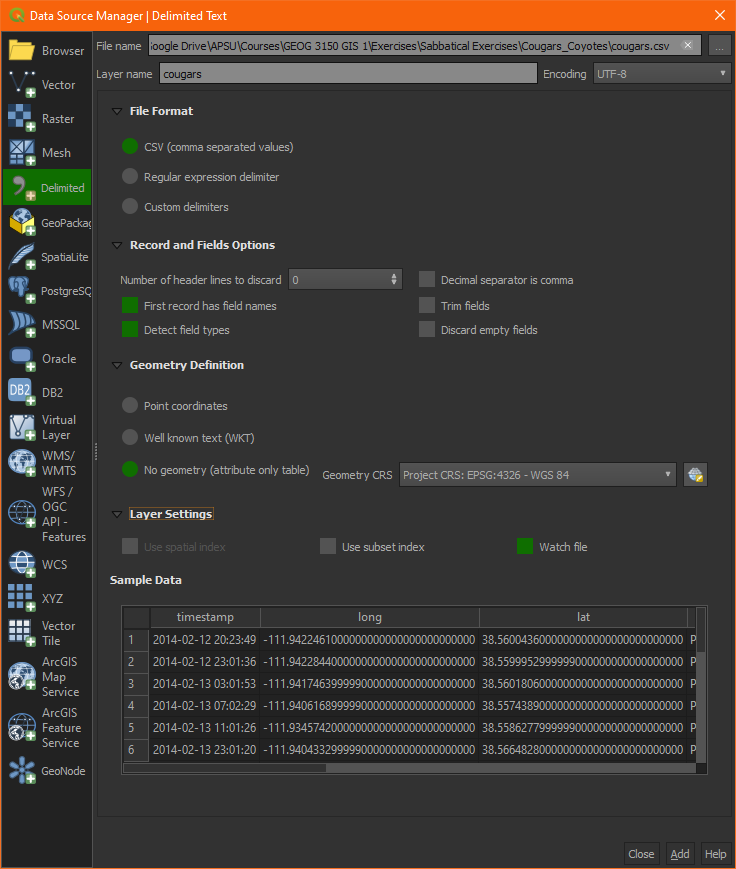

Now you can close the *Delimited Text* window. The resulting dataset is added to your layers as a temporary file. It can still be used for analysis and display purposes, but if you close the project the layer may be removed. To make it a permanent dataset, select the temporary dataset in the layers area, and on the menu bar choose *Layers > Save As…* Alternatively you can right-click or Crtl+click on a Mac and choose *Export > Save features as…*

[figure not shown]

**View directions in **R**

Before you begin, you will need to open the [Ex9 Colab Notebook](https://github.com/chrismgentry/GIS1-Exercise-9/blob/main/GIS1_EX9.ipynb) and insert **tocolab** after *github* in the URL to open in the *Colab Environment*. As you have seen before, R requires various packages to complete certain analyses. In this exercise you will be using **tidyverse, OpenStreetMaps, ggfortify, maptools, and rgeos**. To install and load the packages we will use the following script:

```r
packages <- c("adehabitatHR","ggfortify","OpenStreetMap","tidyverse","maptools","rgeos")
#sapply(packages, install.packages, character.only=TRUE)
sapply(packages, require, character.only=TRUE)
```

Now that you have the packages required for the exercise you can read in the *csv* file and view the resulting dataset. Using the `read.csv` command and a URL to the data on GitHub you will import and examine the data.

```r
cougars <- read.csv("https://raw.githubusercontent.com/chrismgentry/GIS1ex9/main/cougars.csv")
head(cougars)
```

|  | timestamp | long | lat | individual | tag_ident | ind_ident | study_name | utm_east | utm_north | utm_zone | study_tz | study_ts | date | count |
| --- | --- | --- | --- | --- | --- | --- | --- | --- | --- | --- | --- | --- | --- | --- |
| 1 | 2014-02-12 20:23:49 | -111.9422 | 38.56004 | Puma concolor | F64 | F64 | Site fidelity in cougars and coyotes, Utah/Idaho USA (data from Mahoney et al. 2016) | 417905.6 | 4268377 | 12N | Mountain Standard Time | 2014-02-12 13:23:49 | 3/29/2021 | 1 |
| 2 | 2014-02-12 23:01:36 | -111.9423 | 38.56000 | Puma concolor | F64 | F64 | Site fidelity in cougars and coyotes, Utah/Idaho USA (data from Mahoney et al. 2016) | 417902.2 | 4268371 | 12N | Mountain Standard Time | 2014-02-12 16:01:36 | 3/29/2021 | 1 |
| 3 | 2014-02-13 03:01:53 | -111.9417 | 38.56018 | Puma concolor | F64 | F64 | Site fidelity in cougars and coyotes, Utah/Idaho USA (data from Mahoney et al. 2016) | 417949.3 | 4268392 | 12N | Mountain Standard Time | 2014-02-12 20:01:53 | 3/29/2021 | 1 |
| 4 | 2014-02-13 07:02:29 | -111.9406 | 38.55744 | Puma concolor | F64 | F64 | Site fidelity in cougars and coyotes, Utah/Idaho USA (data from Mahoney et al. 2016) | 418044.6 | 4268086 | 12N | Mountain Standard Time | 2014-02-13 00:02:29 | 3/29/2021 | 1 |
| 5 | 2014-02-13 11:01:26 | -111.9346 | 38.55863 | Puma concolor | F64 | F64 | Site fidelity in cougars and coyotes, Utah/Idaho USA (data from Mahoney et al. 2016) | 418572.4 | 4268213 | 12N | Mountain Standard Time | 2014-02-13 04:01:26 | 3/29/2021 | 1 |
| 6 | 2014-02-13 23:01:20 | -111.9404 | 38.56648 | Puma concolor | F64 | F64 | Site fidelity in cougars and coyotes, Utah/Idaho USA (data from Mahoney et al. 2016) | 418070.8 | 4269090 | 12N | Mountain Standard Time | 2014-02-13 16:01:20 | 3/29/2021 | 1 |

You can also plot the simple XY data to examine the spread of the dataset.

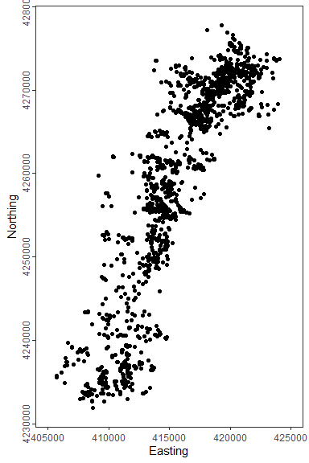

```r
ggplot(cougars) + geom_point(aes(utm_east, utm_north)) +
                  labs(x="Easting", y="Northing") +
                  guides(color=guide_legend("Identification")) +
                  theme_bw() + theme(legend.position = "top") +
                  theme(axis.text.y = element_text(angle=90, hjust=0.5)) +
                  theme(panel.grid.major = element_blank(),
                        panel.grid.minor = element_blank()) +
                  xlim(405000,425000)
```

### 1.1.1 Question No. 1

> How many individuals are being tracked in this dataset?

## 1.2 Step Two: The Analyses

Now that you have the data you can calculate the two home range estimates: *minimum convex polygon* and *kernel density estimation*. The minimum convex polygon (**MCP**) draws the smallest polygon encompassing all the points, while the kernel density estimation (**KDE**) calculates a magnitude-per-unit area from the point features using a function to fit a smoothly tapered surface. For this exercise you will run both analyses and compare the results.

**View Directions in **ArcGIS Pro**

**View Directions in **QGIS**

In the previous step you loaded the relocations and added the layer to your view. Now you will use several tools from the *Processing Toolbox* to complete the analyses including:

- Minimum bounding geometry
- Add geometry attributes
- Heat map (Kernel Density Estimation)
- Raster calculator
- Polygonize (raster to vector)

To create the *minimum convex polygon* you will use the `Minimum bounding geometry` tool that can be found in the *Processing Toolbox* under **Vector geometry**. Alternatively you can search for it in the toolbox search bar. You will use the **cougar** dataset for the *Input layer*, and **Convex hull** for the *Geometry type*. All other options you can leave as the default. Remember this will create a temporary layer which you can choose to make permanent or rename in your layers for clarity.

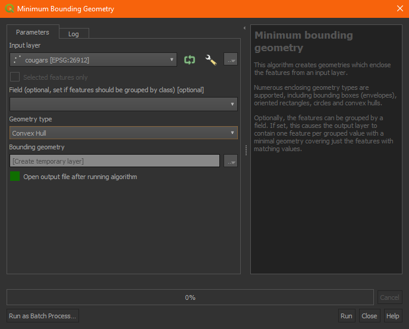

You should now have a *Bounding geometry* polygon in your layers you can style as necessary to display the information. By viewing the *attribute table* you can see the area (in square meters) of the polygon.

Creating the **KDE** estimate will take a few more steps before you can obtain the statistical information for comparison. Because the *kernel density estimation* creates a raster dataset, you will classify the data using the `raster calculator` and convert the classified values to a vector with `polygonize` before examining the statistics.

To begin this analysis you need to open the `Heatmap (Kernel Density Estimation)` tool from **Interpolation** in the *Processing Toolbox*. In the *input layer* you will use the **cougar** dataset, set a *Radius* of 2000, a *pixel size* of 100, and set the *Kernel shape* to *Epanechnikov*.

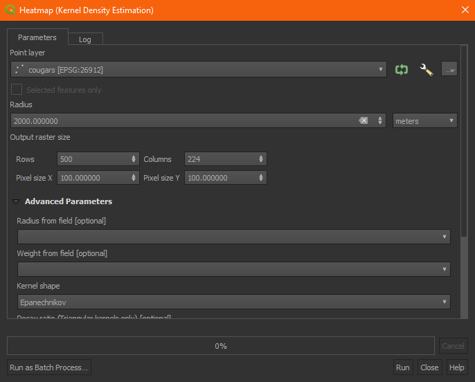

Now click **Run**. This will create a **KDE** and add it to your layers. You can style the *heatmap* using *symbology* under the *properties* menu for the data. IN order to get more information out of this analysis you need to **reclassify** the raster into the following categories:

- Level 1 = 0 to 60, low levels of relocations
- Level 2 = 61 to 120, moderate levels of relocations
- Level 3 = 121 to 180, high levels of relocations
- Level 4 = Greater than 180, very high level of relocations

To do this you will use the `Raster Calculator` located under *Raster* on the *Menu Bar* or under *Raster analysis* in the *Processing Toolbox*. In the *Layers* section you should see the available raster layers in your current project. In the *Expression* box you will paste the following SQL expression:

```
("Heatmap@1" <= 60) * 1 +
(("Heatmap@1" > 60)  AND  ("Heatmap@1" <= 120)) * 2 +
(("Heatmap@1" > 120)  AND  ("Heatmap@1" <= 180)) * 3 +
("Heatmap@1" > 180) * 4
```

Where **“Heatmap@1”** is the name of the *KDE* output from the previous step. This will convert all of the values to a range of 1-4 indicating the level of relocations. In the section for *Reference layer(s) (used for automated extent, cellsize, and CRS)[optional]* you should click the *browse file path* button to add the **Heatmap** (or the name of your *KDE* file). Make the *Cell size* to 100, using the dropdown menu next to the *Output extent [optional]* select **Calculate from Layer** and choose your *Heatmap*. For the *Output CRS [optional]* select the project CRS and then click **Run**.

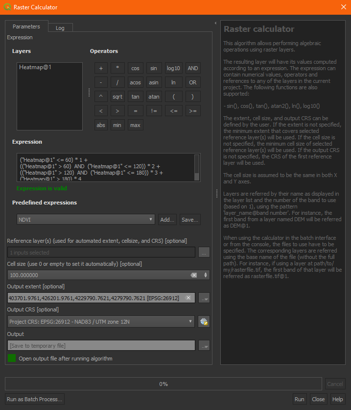

This will add the reclassified heatmap to you layers. Now you can use `Polygonize (raster to vector)` found under *Raster > Conversion* on the menur bar or *GDAL > Raster conversion* in the *Processing Toolbox*. In the *Polygonize (Raster to Vector)* window choose your reclassified KDE created in the previous step as the *Input layer* and click **Run**. This will add another layer (usually called “Vectorized” if set as a temporary file) that turned the raster data to vector polygons. Finally, we need to use the **Add geometry attributes** found under *Vector > Geometry Tools* on the menu bar or *Vector geometry* in the *Processing Toolbox*. This will add columns for **Area** and **Perimeter** to the attribute table for the vectorized dataset. You will need to add the *vectorized* layer as the **Input layer**, *Layer CRS* for the **Calculate using** field and click **Run**.

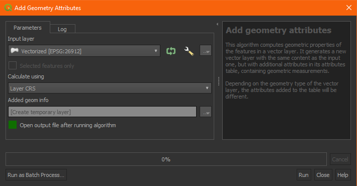

Finally, if you click the **Show Statistical Summary** button on the primary horizontal menu, a new *Statistics* panel will be added to your layout. By selecting the *Added geometry info* layer (or the name of the file from the previous step) and choosing *area* you can see a summary of the statistical information. The total area in the *KDE Estimation* will be found in the **Sum** statistic.

**View Directions in **R**

For this exercise you will use the `adehabitat` package to calculate both the *MCP* and *KDE* polygons. Because this package uses specialized functions you need to convert your XY data to a class of data called *SpatialPoints*. Once the spatial data is created you can run both the MCP and KDE analyses for the dataset you obtained above.

Because the analyses need to be calculated using metric values, you will use the **utm-east** and **utm-north** columns in the dataset to create a set of coordinates with a *SpatialPoints* class that will be used in the calculation of the polygons.

```r
x <- cougars$utm_east
y <- cougars$utm_north
xy <- as.data.frame(cbind(x,y))
coordinates(xy) <- ~x+y
```

With this new *XY* dataset you can now create the **MCP** and **KDE** estimates for the cougar relocations. You will start with the **MCP** polygon. Using the `mcp` function in the `adehabitat` package, you will create the estimated *MCP home range*. Then you will need to convert the resulting *SpatialPolygonsDataFrame* to a format that can be plotted using `ggpolt2`. Currently you will use the `fortify` function, however as functions are deprecated over time, `tidy` as part of the `broom` package can also be used for this process.

```r
mcp.out <- mcp(xy, percent=100, unout="ha")
mcp.poly <- fortify(mcp.out)
```

In the script above you can see the area of the *minimum convex polygon* is being measured in hectares. To determine the area of the *MCP* you can type `mcp.out$area` to print the measurement.

While the *MCP* creates a single bounding polygon, *kernel density estimates* often are used to create multiple polygons that can be used similar to a *hotpsot analysis*. This requires a few additional steps as compared to the *MCP* example above. Before converting the *SpatialPolygonsDataframe* you will need to create multiple estimates from the dataset by varying the percentage level for the home range estimation. Essentially, higher percentage levels will encompass areas with very few relocations and lower percentage levels will encompass areas with a dense number of relocations. For this analysis you will create estimates based on:

- 100% level = includes low to very high levels of relocations
- 75% level = includes moderate to very high levels of relocations
- 50% level = includes high to very high levels of relocations
- 25% level = includes only very high level of relocations

Once these estimates are created you will need to `fortify` each of the polygons so they can be displayed with `ggplot2`.

```r
kde <- kernelUD(xy, h=2000, kern="epa", grid=100)
kde100 <- getverticeshr(kde, 100, unout="ha")
kde75 <- getverticeshr(kde, 75, unout="ha")
kde50 <- getverticeshr(kde, 50, unout="ha")
kde25 <- getverticeshr(kde, 25, unout="ha")
kde.poly100 <- fortify(kde100)
kde.poly75 <- fortify(kde75)
kde.poly50 <- fortify(kde50)
kde.poly25 <- fortify(kde25)
```

In these KDE scripts you can print the area (hectares) of any polygon by typing `kde##$area`, where ## is the *kde* value from the scripts above. Viewing the area of **kde100** will allow you to view the entire area estimated by the analysis since it includes all levels of relocation.

### 1.2.1 Question No. 2

> What is the area of the Minimum Convex Polygon?  
> What is the area of the Kernel Density Estimation?

## 1.3 Step Three: The Visualization

In order to view our data *in situ* we need to add a basemap to our view. While we could add various base layers such as topo or terrain maps, in this case we are going to use satellite imagery.

**View directions in **ArcGIS Pro**

**View directions in **QGIS**

In a previous exercise you added XYZ tiles to your QGIS Browser. Remember to add **ESRI Satellite Imagery** to your broswer you need to Right-Click (CRTL+click on Mac) on *XYZ Tiles* and click **“New Connection”** and add the following URL:

```
https://server.arcgisonline.com/ArcGIS/rest/services/World_Imagery/MapServer/tile/{z}/{y}/{x}
```

You can now click and drag ESRI Satellite into the layer to view the satellite imagery. Remember to arrange your layers so that you can visualize all of the data you are interesting in examining.

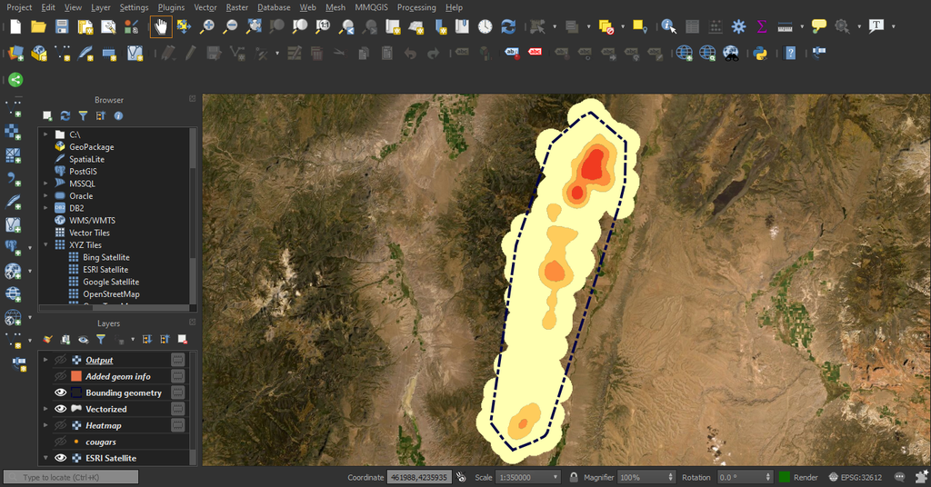

**View directions in **R**

To obtain imagery for this project you are again going to use `OpenStreetMap` to connect to **Bing Aerial Imagery**. Although you used the UTM values for the analysis, *OpenStreetMap* only uses geographic coordinates for their imagery. So you will obtain the image first and then reproject it to the appropriate UTM zone.

```r
imagery <- openmap(c(max(cougars$lat+0.05),min(cougars$long-0.05)),
                   c(min(cougars$lat-0.07),max(cougars$long+0.05)),
                   type = "bing")
```

Now you will convert the imagery projection from geographic coordinates to UTM Zone 12.

```r
imagery_utm <- openproj(imagery,
                        projection = "+proj=utm +zone=12 +datum=WGS84 +units=m +no_defs")
```

With this imagery now you can plot the *MCP* and *KDE* polygons as well as the data points if necessary.

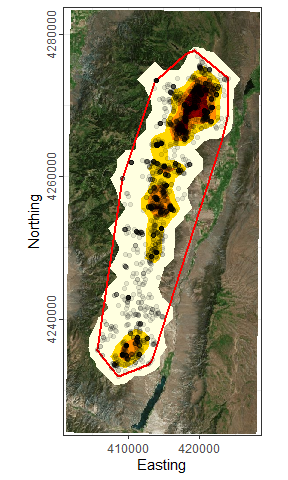

```r
autoplot.OpenStreetMap(imagery_utm, expand = TRUE) +
theme_bw() + theme(legend.position = "bottom") +
geom_polygon(data = kde.poly100, aes(x=long, y=lat, group=group), color = NA, fill = 'lightyellow') +
geom_polygon(data = kde.poly75, aes(x=long, y=lat, group=group), color = NA, fill = 'gold') +
geom_polygon(data = kde.poly50, aes(x=long, y=lat, group=group), color = NA, fill = 'darkorange') +
geom_polygon(data = kde.poly25, aes(x=long, y=lat, group=group), color = NA, fill = 'darkred') +
geom_polygon(data = mcp.poly, aes(x=long, y=lat), color = "red", fill = NA, alpha = 0.8, size = 1) +
geom_point(data = cougars, aes(x=utm_east, y=utm_north), alpha = 0.1) +
labs(x="Easting", y="Northing") + guides(color=guide_legend("Identifier")) +
theme(legend.position="bottom") +
theme(axis.text.y = element_text(angle=90, hjust=0.5))
```

### 1.3.1 Question No. 3

> What steps would you take to differentiate between the individual cougars in this visualization?

## 1.4 Step Four: The Proposal

Now that you have all of the data necessary to determine the feasibility of the **“Grassy Valley Trail”**, you need to add the proposed trail to assess the impact it may have on the cougar population.

**View directions in **ArcGIS Pro**

**View directions in **QGIS**

In the first step you should have downloaded the **hiking_trails** dataset from *GitHub*. If you skipped that step you will need to download the [dataset](https://raw.githubusercontent.com/chrismgentry/GIS1-Exercise-9/main/Data/hiking_trail.csv) now. Similarly to step one, the data is formatted as a *.csv* file so you will need to use *Add Delimited Text Layer* to import the dataset. Once added to your layers you can use the **points to path** tool located in *Vector creation* in the *Processing Toolbox*. In the *Input point layer* parameter choose the **hiking_trail** dataset and in *Order field* choose **node**. You can leave the remainder of the options as default and click **Run**.

[figure not shown]

Now you should have a line representing the proposed **“Grass Valley Trail”** that you can style appropriately to help examine all of the data.

**View directions in **R**

Similarly to step one, you are going to use `read.csv` and a URL from GitHub to import the data for the proposed **“Grass Valley Trail”**.

```r
trail <- read.csv('https://raw.githubusercontent.com/chrismgentry/GIS1ex9/main/hiking_trail.csv')
```

In the previous step you created a visualization that allowed you to overlay the *MCP* and *KDE* polygons on aerial imagery as well as the relocations. To convert the **“Grass Valley Trail”** import from above, which is point data, to a line, you need to add the following script to visualization from above:

```
geom_path(data = trail, aes(x = x ,y = y), size = 1, linetype = 1)
```

Remember, `ggplot2` draws each layer over the previous. So if you want the proposed trail to be the top layer, it should be the last one drawn.

### 1.4.1 Question No. 4

> Does the trail cross any areas calculated as *high* or *very high* use based on the *KDE* analysis?

# 2 The Decision

Recall that *Grass Valley Trail Committee* has asked you to assess the impact of the proposed hiking trail on the mountain lion habitat and potential risk to visitors. Based on the analyses above, complete a lab write-up that addresses the following questions:

- Explain to the committee the process you used to determine the risks of the proposed trail.
- Describe the difference between the two types of home range analyses. How would this potentially impact the decisions made by the committee?
- What portion of the proposed trail has the highest likelihood to traverse areas of the *Sevier Plateau* that are frequently (high to very high categories) used by the tracked cougars?

Finally, provide a recommendation for the committee on how the proposed trail can be completed with as little interaction as possible with the cougar habitat. Include a visualization (whether digital or analog) that helps provide additional details for your recommendation.